# Supplementary Figures - Network-based analysis of genome-wide biobank data boosts discovery of genetic associations in psoriasis

Abstract

Psoriasis is a common autoimmune disease with a strong genetic component. Targeting the *IL-23/IL-17* pathways for the treatment of moderate-severe psoriasis has proven successful, which makes it a good benchmark for other drug discovery approaches. Genome Wide Association Studies (GWAS) identify genetic loci associated with a phenotype (e.g. disease). However, using identified loci to understand the disease mechanisms remains challenging. In response, gene networks methods that consider gene-gene relationships have been developed. In a previous study, we showed that the combination of network methods improved the power, reproducibility, and interpretability of those approaches on a small cohort of breast cancer patients. The goal of the present study is to benchmark the performance of the same combination of network methods on a psoriasis cohort from the UK biobank (with a particular interest on the *IL-23/IL-17* pathways). By applying this method, we identified well known psoriasis genes, demonstrating the viability of our approach. Our method further identified a small set of genes of the MRPL family robustly associated with psoriasis, demonstrating that this approach can provide insights into the potential disease mechanisms. Our study also shows that our method is applicable to large-scale biobank data to produce novel findings, even in well-studied diseases with strong genetic signal.

## Contents

1. Networks produced by each method — Graphs from Heinz, HotNet2, SigMod, dmGWAS, LEAN, MAGMABH, cGWAS and MAGMABH+cGWAS, with the number of genes each selected.
2. Stable consensus network (258 genes) — known gene lists — Genes selected in ≥ 7 of 25 solutions, highlighting overlap with the Ran, Tsoi, Dand and Zhang gene lists.
3. Genes selected across multiple gene sets (bar chart) — Declining bar chart of how many genes appear in at least 1, 2, 3… of the 25 gene lists (1,969 at ≥ 1; 1,094 at ≥ 2).
4. Sensitivity of the stable consensus to the threshold — Networks for Set1 … Set25 (genes in at least k of the 25 lists from 5 folds × 5 methods); Set22–25 are empty.
5. Stable consensus network (258 genes) — signalling pathways — Same 258-gene network, highlighting genes in IL-17, IL-23, TNF, IL-1, IFN-γ, IL-22, IL-6, NF-κB, JAK-STAT, MAPK, PI3K-AKT and WNT pathways.
6. Stable consensus network (258 genes) — methods and gene source — Same network with pies showing which methods selected each gene and labels showing cGWAS / MAGMABH support.
7. Non-network prioritisation (MAGMA + Benjamini-Hochberg) — Network view of the genes from the MAGMA gene-analysis step after Benjamini-Hochberg correction.
8. Consensus sensitivity — number of methods required — Consensus networks for genes selected by ≥ 1 to 5 methods, shown as panels A–E.
9. Robustness to the prior-knowledge network — Consensus networks rebuilt with HINT (a), IID (b), IntAct (c) and STRING (d) instead of BioGRID.
10. Comparison between datasets — (a) this study’s data excluding the MHC region and with covariates; (b) consensus network from FinnGen psoriasis summary statistics.

## Networks produced by each method

Graphs from Heinz, HotNet2, SigMod, dmGWAS, LEAN, MAGMABH, cGWAS and MAGMABH+cGWAS, with the number of genes each selected.

↑ Back to contents

```r
library(igraph)
library(tidygraph)
library(magrittr)
library(ggrepel)
library(tidyverse)
library(cowplot)
suppressMessages(library(network))
suppressMessages(library(sna))
library(ggnetwork)
library(scatterpie)
library(ggnewscale)

# Transparent ggplot theme (no panel, plot or legend background, no grid lines), so the figures can be placed on any background.
theme_transparent <- theme(panel.background = element_rect(fill = "transparent"), # bg of the panel
                           plot.background = element_rect(fill = "transparent", color = NA), # bg of the plot
                           panel.grid.major = element_blank(), # get rid of major grid
                           panel.grid.minor = element_blank(), # get rid of minor grid
                           legend.background = element_rect(fill = "transparent", color = NA), # get rid of legend bg
                           legend.box.background = element_rect(fill = "transparent", color = NA) # get rid of legend panel bg
)

theme_set(theme_cowplot() + theme_transparent)

ppi <- read_tsv('data/biogrid_mv_physical_4.4.249_tab2_onlyhuman_9606_interactorsAB.tsv', col_types = 'cc') %>%
  select(`Official Symbol Interactor A`, `Official Symbol Interactor B`) %>%
  graph_from_data_frame(directed = FALSE) %>%
  as_tbl_graph

methods <- c('Heinz','HotNet2', 'SigMod', 'cGWAS', 'MAGMABH', 'dmGWAS', 'LEAN', 'MAGMABHcGWAS')

method_palette <- c('Heinz' = '#73471f',
                    'HotNet2' = '#377eb8', 'SigMod' = '#f4888a', 'All' = 'gray50',
                    'Consensus' = 'black', 'MAGMABH' = '#abdda4', 'cGWAS' = '#fdae61', 'dmGWAS' = '#80cdc1', 'LEAN' = '#4d9221')

genesrc_palette <- c('MAGMABH' = '#abdda4', 'cGWAS' = '#fdae61', 'MAGMABH and cGWAS' = '#d3c783', 'Methods only' = '#ffffff')

plot_network <- function(net, selected_nodes) {

  graph <- activate(net, nodes) %>%
    filter(name %in% selected_nodes)
  class(graph) <- c('igraph','tbl_graph')

  ggnetwork(graph) %>%
    ggplot(aes(x = x, y = y, xend = xend, yend = yend)) +
    geom_edges(color = '#3282b8') +
    geom_nodes(color = '#233142', size = 4) +
    #geom_label(aes(label = name),
    #                 size = 2) +
    ggtitle(' ') +
    theme_blank() + theme_transparent +
    theme(title = element_text(hjust = 1, face = 'bold'))
}

# heinz
heinz <- read_tsv('data/heinz/selected_genes_split_1.heinz.txt', col_types = 'c')$gene
heinz_plt <- plot_network(ppi, heinz)
heinz_plt_square <- heinz_plt + coord_fixed(ratio = 1) # Add coord_fixed(ratio = 1) to make the plot square

# hotnet2
hotnet2 <- read_tsv('data/hotnet2/selected_genes_split_1.hotnet2.tsv', col_types = 'cc')$gene
hotnet2_plt <- plot_network(ppi, hotnet2)
hotnet2_plt_square <- hotnet2_plt + coord_fixed(ratio = 1)

# sigmod
sigmod <- read_tsv('data/sigmod/selected_genes_split_1.sigmod.txt', col_types = 'c')$gene
sigmod_plt <- plot_network(ppi, sigmod)
sigmod_plt_square <- sigmod_plt + coord_fixed(ratio = 1)

# dmgwas
dmgwas <- read_tsv('data/dmgwas/selected_genes_split_1.dmgwas.txt', col_types = 'c')$gene
dmgwas_plt <- plot_network(ppi, dmgwas)
dmgwas_plt_square <- dmgwas_plt + coord_fixed(ratio = 1)

# lean
lean <- read_tsv('data/lean/selected_genes_split_1.lean.txt', col_types = 'c')$gene
lean_plt <- plot_network(ppi, lean)
lean_plt_square <- lean_plt + coord_fixed(ratio = 1)

# Classical GWAS
cgwas_genes <- read_tsv('data/pso.genes.annot_gene_ids_names.tsv', col_types = 'c')$Gene %>% unique()
cgwas_plt <- plot_network(ppi, cgwas_genes)
cgwas_plt_square <- plot_network(ppi, cgwas_genes) + coord_fixed(ratio = 1)
# Magma output after Benjamini Hochberg correction
magmabh <- read_tsv('data/pso.scores.genes.out_converted_pruned_bhcorrection.tsv',
                    col_types = 'iiciiiiiidnn')$Gene %>% unique()
magmabh_plt <- plot_network(ppi, magmabh)
magmabh_plt_square <- plot_network(ppi, magmabh) + coord_fixed(ratio = 1)
# Magma output together with classical gwas annotation output
magmabh_cgwas <- union(magmabh, cgwas_genes)
magmabh_cgwas_plt <- plot_network(ppi, magmabh_cgwas)
magmabh_cgwas_plt_square <- plot_network(ppi, magmabh_cgwas) + coord_fixed(ratio = 1)
# Magma output intersected with classical gwas annotation output
magmabh_and_cgwas <- intersect(magmabh, cgwas_genes)
magmabh_and_cgwas_plt <- plot_network(ppi, magmabh_and_cgwas)
magmabh_and_cgwas_plt_square <- plot_network(ppi, magmabh_and_cgwas) + coord_fixed(ratio = 1)
topology_panel <- plot_grid(heinz_plt, hotnet2_plt, sigmod_plt, dmgwas_plt, lean_plt, magmabh_plt, cgwas_plt, magmabh_cgwas_plt,
                            labels = c('\nHeinz','\nHotNet2','\nSigMod', 'dmGWAS', 'LEAN', 'MAGMABH', '\ncGWAS', 'MAGMABH+cGWAS'),
                            label_size = 30,
                            nrow = 4,
                            ncol = 2)

topology_panel
```

[figure not shown]

Networks or undirected simple graphs produced by Heinz (Dittrich et al. 2008), HotNet2 (Leiserson et al. 2015), SigMod (Liu et al. 2017), dmGWAS (Wang et al. 2015), LEAN (Gwinner et al. 2017), MAGMABH which corresponds to MAGMA output (de Leeuw et al. 2015) after Benjamini-Hochberg correction, cGWAS (classical GWAS) which corresponds to mapping significant SNPs to the corresponding gene, MAGMABH+cGWAS which corresponds to joining both genes from MAGMABH and cGWAS. Heinz selected 693 genes; HotNet2 selected 454 genes; SigMod selected 204 genes; dmGWAS selected 147 genes; LEAN selected 22 genes; MAGMABH selected 432 genes; cGWAS selected 240 genes; MAGMABH+cGWAS selected 448 genes

## Stable consensus network (258 genes) — known gene lists

Genes selected in ≥ 7 of 25 solutions, highlighting overlap with the Ran, Tsoi, Dand and Zhang gene lists.

↑ Back to contents

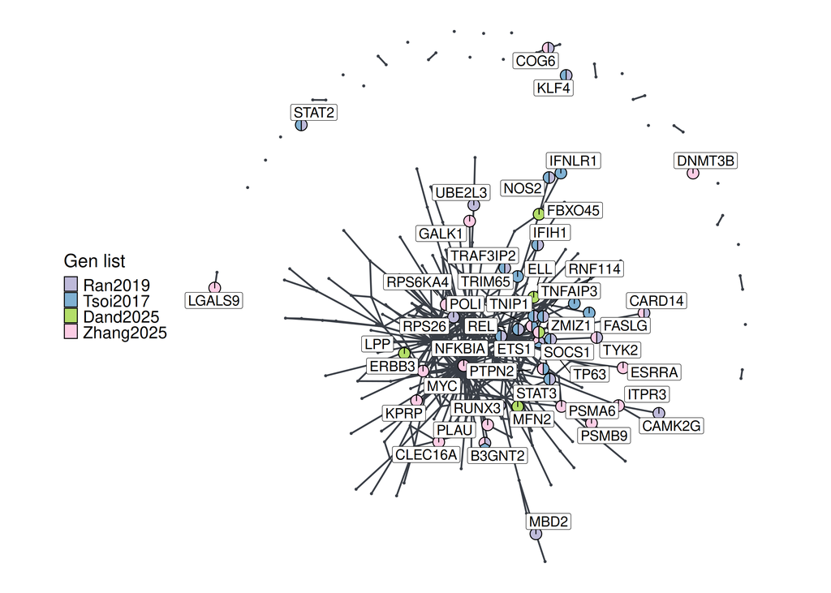

Stable consensus network comprising 258 genes built by choosing those genes selected in at least 7 out of 25 solutions. This network highlights genes in common with known gene lists from Ran et al. (2019, Tsoi et al. (2017), Dand et al. (2025) and Zhang et al. (2025).

```r
ran_psoriasis_genes <- read_tsv('data/gene_lists/ran_psoriasis_genes.tsv',
                                col_types = 'cc') %>%
  select(gene) %>%
  mutate(gene = toupper(gene))

tsoi_psoriasis_genes <- read_csv('data/gene_lists/tsoi_psoriasis_genes.csv',
                                 col_types = 'cc') %>%
  select(`Closest Gene`)%>%
  mutate(`Closest Gene` = toupper(`Closest Gene`))

dand_psoriasis_genes <- read_csv('data/gene_lists/dand_psoriasis_closest_protein_genes.tsv',
                                 col_types = 'c') %>%
  select(gene) %>%
  mutate(gene = toupper(gene))

zhang_psoriasis_genes <- read_csv('data/gene_lists/zhang_psoriasis_genes.tsv',
                                  col_types = 'c') %>%
  select(gene) %>%
  mutate(gene = toupper(gene))

gen_list <- c('Ran2019', 'Tsoi2017', 'Dand2025', 'Zhang2025')
gen_list_palette <- c('Ran2019' = '#bebada', 'Tsoi2017' = '#80b1d3', 'Dand2025' = '#b3de69', 'Zhang2025' = '#fccde5')

# compilation of genes selected by all the methods across the different datasets.
heinz_genes <- c()
hotnet2_genes <- c()
sigmod_genes <- c()
dmgwas_genes <- c()
lean_genes <- c()

nsplits <- 5 # Number of splits applied to the data.
nmethods <- 5 # Number of biological network methods used

for (j in 1:nsplits) {
  # Read genes selected by Heinz
  file_name <- paste0("data/stable_consensus/data_splits/", "data_split_", j, "/heinz/selected_genes_split_", j, ".heinz.txt")
  heinz_genes <- unique(c(heinz_genes, read_tsv(file_name, col_types = 'c')$gene))

  # Read genes selected by HotNet2
  file_name <- paste0("data/stable_consensus/data_splits/", "data_split_", j, "/hotnet2/selected_genes_split_", j, ".hotnet2.tsv")
  hotnet2_genes <- unique(c(hotnet2_genes, read_tsv(file_name, col_types = 'cc')$gene))

  # Read genes selected by SigMod
  file_name <- paste0("data/stable_consensus/data_splits/", "data_split_", j, "/sigmod/selected_genes_split_", j, ".sigmod.txt")
  sigmod_genes <- unique(c(sigmod_genes, read_tsv(file_name, col_types = 'c')$gene))

  # Read genes selected by DMGWAS
  file_name <- paste0("data/stable_consensus/data_splits/", "data_split_", j, "/dmgwas/selected_genes_split_", j, ".dmgwas.txt")
  dmgwas_genes <- unique(c(dmgwas_genes, read_tsv(file_name, col_types = 'c')$gene))

  # Read genes selected by Lean
  file_name <- paste0("data/stable_consensus/data_splits/", "data_split_", j, "/lean/selected_genes_split_", j, ".lean.txt")
  lean_genes <- unique(c(lean_genes, read_tsv(file_name, col_types = 'c')$gene))
}


# powersets
gene_lists_subsets <- c()
gene_lists_src <- list()

for (j in 1:nsplits) {
  file_name <- paste0("data/stable_consensus/data_splits/","data_split_", j, "/heinz/selected_genes_split_", j, ".heinz.txt")
  gene_lists_src[[length(gene_lists_src) + 1]] <- read_tsv(file_name, col_types = 'c')$gene

  file_name <- paste0("data/stable_consensus/data_splits/","data_split_", j, "/hotnet2/selected_genes_split_", j, ".hotnet2.tsv")
  gene_lists_src[[length(gene_lists_src) + 1]] <- read_tsv(file_name, col_types = 'cc')$gene

  file_name <- paste0("data/stable_consensus/data_splits/","data_split_", j, "/sigmod/selected_genes_split_", j, ".sigmod.txt")
  gene_lists_src[[length(gene_lists_src) + 1]] <- read_tsv(file_name, col_types = 'c')$gene

  file_name <- paste0("data/stable_consensus/data_splits/","data_split_", j, "/dmgwas/selected_genes_split_", j, ".dmgwas.txt")
  gene_lists_src[[length(gene_lists_src) + 1]] <- read_tsv(file_name, col_types = 'c')$gene

  file_name <- paste0("data/stable_consensus/data_splits/","data_split_", j, "/lean/selected_genes_split_", j, ".lean.txt")
  gene_lists_src[[length(gene_lists_src) + 1]] <- read_tsv(file_name, col_types = 'c')$gene
}

for (gene_list in gene_lists_src) {
  for (gene in gene_list) {
    if (gene %in% names(gene_lists_subsets)) {
      gene_lists_subsets[gene] <- gene_lists_subsets[gene] + 1
    } else {
      gene_lists_subsets[gene] <- 1
    }
  }
}

# Calculate the number of genes appearing in at least 1, 2, 3, ..., nmethods * nsplits lists
max_occurrences <- nmethods * nsplits

# Loop through the process n times
for (i in seq(1, max_occurrences)) {
  # Genes in at least i solutions
  gene_set <- names(gene_lists_subsets[gene_lists_subsets >= i])
}

# Genes in at least 7 solutions

gene_set7 <- names(gene_lists_subsets[gene_lists_subsets >= 7])
gene_set7_plt <- plot_network(ppi, gene_set7)
# Gene set 7

gset7 <- activate(ppi, nodes) %>%
  filter(name %in% gene_set7) %>%
  mutate(gset7 = TRUE)
class(gset7) <- c('igraph','tbl_graph')

# cGWAS

g_cgwas <- activate(ppi, nodes) %>%
  filter(name %in% cgwas_genes) %>%
  mutate(cgwas_genes = TRUE)
class(g_cgwas) <- c('igraph','tbl_graph')

# MAGMA_BH

g_magmabh <- activate(ppi, nodes) %>%
  filter(name %in% magmabh) %>%
  mutate(magmabh = TRUE)
class(g_magmabh) <- c('igraph','tbl_graph')

# MAGMA_BH and cGWAS

g_magmabh_and_cgwas <- activate(ppi, nodes) %>%
  filter(name %in% magmabh_and_cgwas) %>%
  mutate(magmabh_and_cgwas = TRUE)
class(g_magmabh_and_cgwas) <- c('igraph','tbl_graph')

gset7 <- gset7 %>%
  ggnetwork %>%
  mutate(name = as.character(name))
nodes <- mutate(gset7, Ran2019 = as.numeric(name %in% ran_psoriasis_genes$gene),
                Tsoi2017 =  as.numeric(name %in% tsoi_psoriasis_genes$`Closest Gene`),
                Dand2025 =  as.numeric(name %in% dand_psoriasis_genes$gene),
                Zhang2025 =  as.numeric(name %in% zhang_psoriasis_genes$gene)
                ) %>%
  filter(xend == x & yend == y) %>%
  select(x, y, name, all_of(gen_list)
         ) %>%
  unique

edges <- filter(gset7, xend != x | yend != y)

common_ran_psoriasis_genes <- nodes$name %in% ran_psoriasis_genes$gene
common_tsoi_psoriasis_genes <- nodes$name %in% tsoi_psoriasis_genes$`Closest Gene`
common_dand_psoriasis_genes <- nodes$name %in% dand_psoriasis_genes$gene
common_zhang_psoriasis_genes <- nodes$name %in% zhang_psoriasis_genes$gene
common_all_gen_lists <- common_ran_psoriasis_genes | common_tsoi_psoriasis_genes | common_dand_psoriasis_genes | common_zhang_psoriasis_genes

consensus_pie_gene_lists <- ggplot() +
  geom_edges(data = edges, aes(x = x, y = y, xend = xend, yend = yend),
             color = '#393e46', linewidth = 1) +
  geom_point(data = filter(nodes, !common_all_gen_lists),
             aes(x = x, y = y),
             size = 1, color = '#393e46') +
  geom_scatterpie(data = nodes, aes(x = x, y = y, r=0.011), cols = gen_list) +
  geom_label_repel(data = filter(nodes, common_all_gen_lists),
                   aes(x = x, y = y, label = name),
                   size = 6, point.padding = 1, max.time = 5, max.iter = 20000,
                   max.overlaps = 30) +
  coord_fixed() +
  theme_blank() +
  labs(fill = 'Gen list') +
  scale_fill_manual(values = gen_list_palette) +
  guides(color = "none") +
  theme(legend.position = 'left',
        legend.text = element_text(size = 20, vjust = .2),
        legend.title = element_text(size = 22, vjust = 1)) +
  theme_transparent

consensus_pie_gene_lists
```

## Genes selected across multiple gene sets (bar chart)

Declining bar chart of how many genes appear in at least 1, 2, 3… of the 25 gene lists (1,969 at ≥ 1; 1,094 at ≥ 2).

↑ Back to contents

```r
occurrence_counts <- sapply(1:max_occurrences, function(x) sum(gene_lists_subsets >= x))

# Create a data frame for plotting
occurrence_df <- data.frame(Occurrences = 1:max_occurrences, Frequency = occurrence_counts)

# Plot the data
ggplot(occurrence_df, aes(x = Occurrences, y = Frequency)) +
  geom_bar(stat = "identity", fill = "#016784") +
  geom_text(aes(label = Frequency), vjust = -0.5, size = 6) +
  geom_line(stat = "identity") +
  labs(
    title = "Number of genes appearing in at least n solutions",
    x = "Solutions",
    y = "Number of genes") +
  theme_minimal(base_size = 20)
```

[figure not shown]

Declining bar chart to show the selection of genes across multiple gene sets for the construction of a stable consensus network. The highest bar (at 1 set) contains 1 969 genes, meaning nearly 2 000 genes appear in at least one gene set. This number drops to 1 094 genes appearing in at least 2 gene sets, and continues declining steeply through subsequent thresholds.

## Sensitivity of the stable consensus to the threshold

Networks for Set1 … Set25 (genes in at least k of the 25 lists from 5 folds × 5 methods); Set22–25 are empty.

↑ Back to contents

```r
# Initialize an empty list to store the plots
gene_plots <- vector("list", max_occurrences)

# Loop through the process n times
for (i in seq(1, max_occurrences)) {
  # Genes in at least i solutions
  gene_set <- names(gene_lists_subsets[gene_lists_subsets >= i])
  gene_plots[[i]] <- plot_network(ppi, gene_set)
}
```

[output not shown]

```r
# Create the topology panel
topology_panel <- plot_grid(plotlist = gene_plots,
                            labels = paste0("Set", 1:max_occurrences),
                            label_size = 28)

# Create the plot
sensitivity_plot <- plot_grid(topology_panel,
                align = "v",        # Aligns vertically
                axis = "tblr")         # Aligns the top and bottom axes
sensitivity_plot
```

[figure not shown]

Sensitivity analysis of different thresholds applied for the construction of the stable consensus network. After the running the workflow for constructing the stable consensus, the pipeline produces 25 gene lists corresponding to the subsampling approach (five folds times five methods). Set1 means all the genes selected in at least one gene list, Set2 means all the genes selected in at least two gene lists, Set3 means all the genes selected in at least three gene lists, etc. Set25 means all the genes selected in all gene lists, which in this case is empty together with Set22, Set23 and Set24.

## Stable consensus network (258 genes) — signalling pathways

Same 258-gene network, highlighting genes in IL-17, IL-23, TNF, IL-1, IFN-γ, IL-22, IL-6, NF-κB, JAK-STAT, MAPK, PI3K-AKT and WNT pathways.

↑ Back to contents

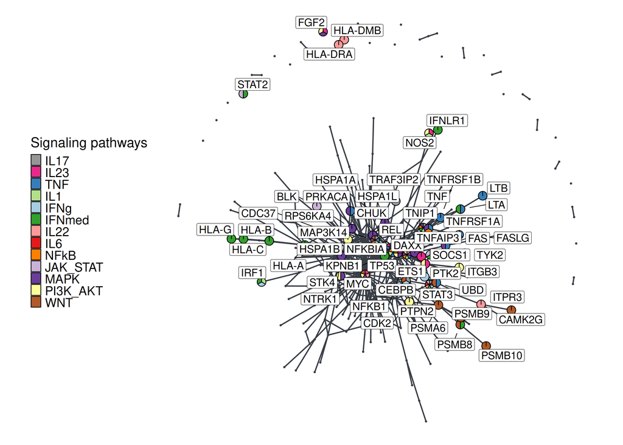

Stable consensus network comprising 258 genes built by choosing those genes selected in at least 7 out of 25 solutions. This network highlights genes in common with L-17, IL-23, TNF, IL-1, IFN-γ, IFN -mediated, IL-22, IL-6, NF-κB, JAK-STAT, MAPK, PI3K-AKT and WNT pathways.

```r
il17_signaling_pathway <- read_tsv('data/pathways/il17_signaling_pathway.tsv',
                                   col_types = 'c') %>%
  select(gene) %>%
  mutate(gene = toupper(gene))

il23_signaling_pathway <- read_tsv('data/pathways/il23_signaling_pathway.tsv',
                                   col_types = 'c') %>%
  select(gene) %>%
  mutate(gene = toupper(gene))

tnf_signaling_pathway <- read_tsv('data/pathways/tnf_signaling_pathway.tsv',
                                  col_types = 'c') %>%
  select(gene) %>%
  mutate(gene = toupper(gene))

il1_signaling_pathway <- read_tsv('data/pathways/il1_signaling_pathway.tsv',
                                  col_types = 'c') %>%
  select(gene) %>%
  mutate(gene = toupper(gene))

ifn_gamma_signaling_pathway <- read_tsv('data/pathways/ifn-gamma_signaling_pathway.tsv',
                                        col_types = 'c') %>%
  select(gene) %>%
  mutate(gene = toupper(gene))

interferons_mediated_signaling_pathway <- read_tsv('data/pathways/interferons-mediated_signaling_pathway.tsv',
                                                   col_types = 'c') %>%
  select(gene) %>%
  mutate(gene = toupper(gene))

il22_signaling_pathway <- read_tsv('data/pathways/il22_signaling_pathway.tsv',
                                   col_types = 'c') %>%
  select(gene) %>%
  mutate(gene = toupper(gene))

il6_signaling_pathway <- read_tsv('data/pathways/il6_signaling_pathway.tsv',
                                  col_types = 'c') %>%
  select(gene) %>%
  mutate(gene = toupper(gene))

il9_signaling_pathway <- read_tsv('data/pathways/il9_signaling_pathway.tsv',
                                  col_types = 'c') %>%
  select(gene) %>%
  mutate(gene = toupper(gene))

nfkb_signaling_pathway <- read_tsv('data/pathways/nfkb_signaling_pathway.tsv',
                                   col_types = 'c') %>%
  select(gene) %>%
  mutate(gene = toupper(gene))

jak_stat_signaling_pathway <- read_tsv('data/pathways/jak-stat_signaling_pathway.tsv',
                                       col_types = 'c') %>%
  select(gene) %>%
  mutate(gene = toupper(gene))

mapk_signaling_pathway <- read_tsv('data/pathways/mapk_signaling_pathway.tsv',
                                   col_types = 'c') %>%
  select(gene) %>%
  mutate(gene = toupper(gene))

pi3k_akt_signaling_pathway <- read_tsv('data/pathways/pi3k-akt_signaling_pathway.tsv',
                                       col_types = 'c') %>%
  select(gene) %>%
  mutate(gene = toupper(gene))

wnt_signaling_pathway <- read_tsv('data/pathways/wnt_signaling_pathway.tsv',
                                  col_types = 'c') %>%
  select(gene) %>%
  mutate(gene = toupper(gene))

pathways <- c('IL17','IL23', 'TNF', 'IL1', 'IFNg', 'IFNmed', 'IL22', 'IL6', 'IL9', 'NFkB', 'JAK_STAT', 'MAPK', 'PI3K_AKT', 'WNT')

pathways_palette <- c('IL17' = '#969696', 'IL23' = '#e7298a', 'TNF' = '#377eb8', 'IL1' = '#b2df8a', 'IFNg' = '#a6cee3', 'IFNmed' = '#33a02c', 'IL22' = '#fb9a99', 'IL6' = '#e31a1c', 'IL9' = '#fdbf6f', 'NFkB' = '#ff7f00', 'JAK_STAT' = '#cab2d6', 'MAPK' = '#6a3d9a', 'PI3K_AKT' = '#ffff99', 'WNT' = '#b15928')

nodes <- mutate(gset7, IL17 = as.numeric(name %in% il17_signaling_pathway$gene),
                IL23 = as.numeric(name %in% il23_signaling_pathway$gene),
                TNF =  as.numeric(name %in% tnf_signaling_pathway$gene),
                IL1 =  as.numeric(name %in% il1_signaling_pathway$gene),
                IFNg =  as.numeric(name %in% ifn_gamma_signaling_pathway$gene),
                IFNmed =  as.numeric(name %in% interferons_mediated_signaling_pathway$gene),
                IL22 =  as.numeric(name %in% il22_signaling_pathway$gene),
                IL6 =  as.numeric(name %in% il6_signaling_pathway$gene),
                IL9 =  as.numeric(name %in% il9_signaling_pathway$gene),
                NFkB =  as.numeric(name %in% nfkb_signaling_pathway$gene),
                JAK_STAT =  as.numeric(name %in% jak_stat_signaling_pathway$gene),
                MAPK =  as.numeric(name %in% mapk_signaling_pathway$gene),
                PI3K_AKT =  as.numeric(name %in% pi3k_akt_signaling_pathway$gene),
                WNT =  as.numeric(name %in% wnt_signaling_pathway$gene)
                ) %>%
  filter(xend == x & yend == y) %>%
  select(x, y, name, all_of(pathways)
         ) %>%
  unique

edges <- filter(gset7, xend != x | yend != y)

common_il17_pathway <- nodes$name %in% il17_signaling_pathway$gene
common_il23_pathway <- nodes$name %in% il23_signaling_pathway$gene
common_tnf_pathway <- nodes$name %in% tnf_signaling_pathway$gene
common_il1_pathway <- nodes$name %in% il1_signaling_pathway$gene
common_ifn_gamma_pathway <- nodes$name %in% ifn_gamma_signaling_pathway$gene
common_ifnmed_pathway <- nodes$name %in% interferons_mediated_signaling_pathway$gene
common_il22_pathway <- nodes$name %in% il22_signaling_pathway$gene
common_il6_pathway <- nodes$name %in% il6_signaling_pathway$gene
common_il9_pathway <- nodes$name %in% il9_signaling_pathway$gene
common_nfkb_pathway <- nodes$name %in% nfkb_signaling_pathway$gene
common_jak_stat_pathway <- nodes$name %in% jak_stat_signaling_pathway$gene
common_mapk_pathway <- nodes$name %in% mapk_signaling_pathway$gene
common_pi3k_akt_pathway <- nodes$name %in% pi3k_akt_signaling_pathway$gene
common_wnt_pathway <- nodes$name %in% wnt_signaling_pathway$gene
common_all_pathways <- (common_il17_pathway | common_il23_pathway | common_tnf_pathway |
                        common_il1_pathway | common_ifn_gamma_pathway | common_ifnmed_pathway |
                        common_il22_pathway | common_il6_pathway | common_il9_pathway |
                        common_nfkb_pathway | common_jak_stat_pathway | common_mapk_pathway |
                        common_pi3k_akt_pathway | common_wnt_pathway)

consensus_pie_pathways <- ggplot() +
  geom_edges(data = edges, aes(x = x, y = y, xend = xend, yend = yend),
             color = '#393e46', linewidth = 1) +
  geom_point(data = filter(nodes, !common_all_pathways),
             aes(x = x, y = y),
             size = 1, color = '#393e46') +
  geom_scatterpie(data = nodes, aes(x = x, y = y, r=0.011), cols = pathways) +
  geom_label_repel(data = filter(nodes, common_all_pathways),
                   aes(x = x, y = y, label = name),
                   size = 6, point.padding = 1, max.time = 5, max.iter = 20000,
                   max.overlaps = 50) +
  coord_fixed() +
  theme_blank() +
  labs(fill = 'Signaling pathways') +
  scale_fill_manual(values = pathways_palette) +
  guides(color = "none") +
  theme(legend.position = 'left',
        legend.text = element_text(size = 20, vjust = .2),
        legend.title = element_text(size = 22, vjust = 1)) +
  theme_transparent

consensus_pie_pathways
```

## Stable consensus network (258 genes) — methods and gene source

Same network with pies showing which methods selected each gene and labels showing cGWAS / MAGMABH support.

↑ Back to contents

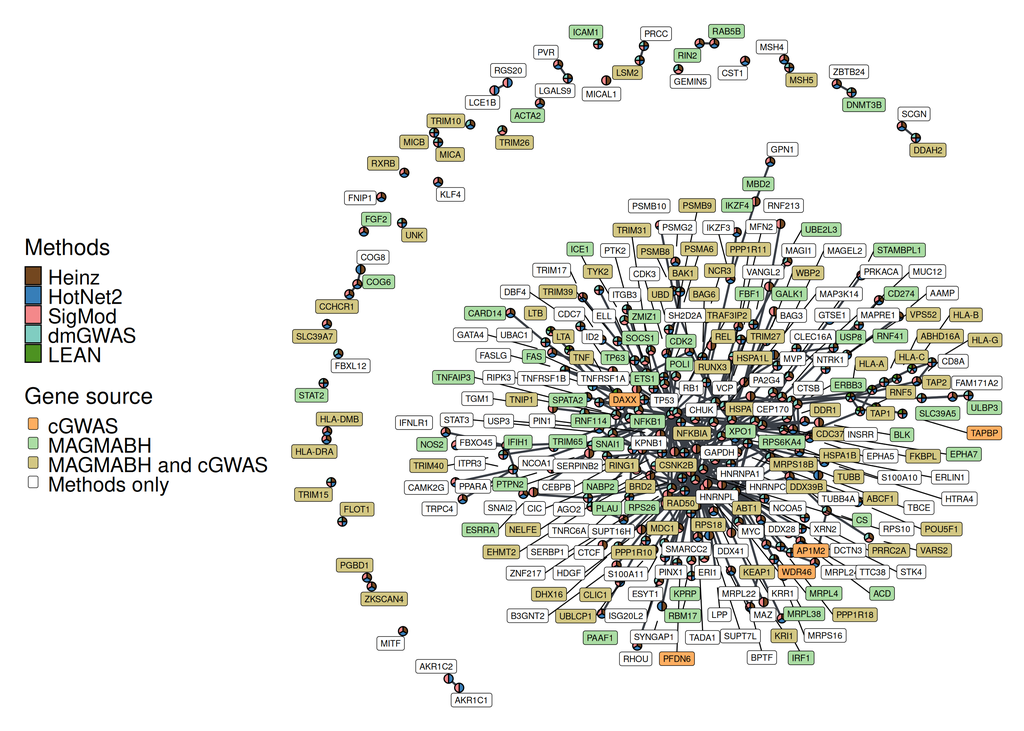

Stable consensus network built by choosing those genes selected in at least 7 out of 25 solutions. There are 258 genes in the network.

```r
gene_set7 <- names(gene_lists_subsets[gene_lists_subsets >= 7])
gene_set7_plt <- plot_network(ppi, gene_set7)
# Gene set 7

gset7 <- activate(ppi, nodes) %>%
  filter(name %in% gene_set7) %>%
  mutate(gset7 = TRUE)
class(gset7) <- c('igraph','tbl_graph')

consensus_gg <- function(gset, g_cgwas, g_magmabh, g_magmabh_and_cgwas,
                         cgwas_genes, magmabh, magmabh_and_cgwas) {

  # gset <- gset %>% to_undirected

  gset <- gset %>% graph_join(g_magmabh_and_cgwas, by = c('name')) %>%
    graph_join(g_cgwas, by = c('name')) %>%
    graph_join(g_magmabh, by = c('name')) %>%
    to_undirected %>%
    mutate(magmabh_and_cgwas = ifelse(is.na(magmabh_and_cgwas), FALSE, magmabh_and_cgwas),
           cgwas_genes = ifelse(is.na(cgwas_genes), FALSE, cgwas_genes),
           magmabh = ifelse(is.na(magmabh), FALSE, magmabh)) %>%
    filter(name %in% V(gset)$name)

  set.seed(42)   # fixes the network layout for reproductibility
  gset %>%
  ggnetwork %>%
  mutate(name = as.character(name))
}

consensus <- consensus_gg(gset7, g_cgwas, g_magmabh, g_magmabh_and_cgwas,
                          cgwas_genes, magmabh, magmabh_and_cgwas)
nodes <- mutate(consensus,
                Heinz = as.numeric(name %in% heinz_genes),
                HotNet2 = as.numeric(name %in% hotnet2_genes),
                SigMod = as.numeric(name %in% sigmod_genes),
                dmGWAS = as.numeric(name %in% dmgwas_genes),
                LEAN = as.numeric(name %in% lean_genes),
                cGWAS = as.numeric(cgwas_genes),
                MAGMABH = as.numeric(magmabh),
                MAGMABHcGWAS = as.numeric(magmabh_and_cgwas)
                ) %>%
  filter(xend == x & yend == y) %>%
  select(x, y, name, all_of(methods)) %>%
  unique

nodes <- nodes %>%
  mutate(label_group = case_when(
    MAGMABHcGWAS == 1 ~ 'MAGMABH and cGWAS',
    MAGMABH == 1 ~ 'MAGMABH',
    cGWAS == 1 ~ 'cGWAS',
    TRUE ~ 'Methods only')
  )

edges <- filter(consensus, xend != x | yend != y)

consensus_pie_methods <- ggplot() +
  geom_edges(data = edges, aes(x = x, y = y, xend = xend, yend = yend),
             color = '#393e46', linewidth = 1) +
  geom_scatterpie(data = nodes, aes(x = x, y = y, r=0.007), cols = setdiff(methods, c('MAGMABH', 'cGWAS', 'MAGMABHcGWAS'))) +
  scale_fill_manual(name = "Methods", values = method_palette) +
  ggnewscale::new_scale_fill() +
  geom_label_repel(data = nodes,
                   aes(x = x, y = y, label = name, fill = label_group),
                   size = 3, point.padding = 1, max.time = 5, max.iter = 20000,
                   max.overlaps = 100) +
  scale_fill_manual(name = "Gene source", values = genesrc_palette) +
  coord_fixed() +
  theme_blank() +
  guides(color = "none", fill = guide_legend(
    override.aes = aes(label = "  ")
  )) +
  theme(legend.position = 'left',
        legend.text = element_text(size = 20, vjust = .2),
        legend.title = element_text(size = 22, vjust = 1)) +
  theme_transparent

consensus_pie_methods
```

## Non-network prioritisation (MAGMA + Benjamini-Hochberg)

Network view of the genes from the MAGMA gene-analysis step after Benjamini-Hochberg correction.

↑ Back to contents

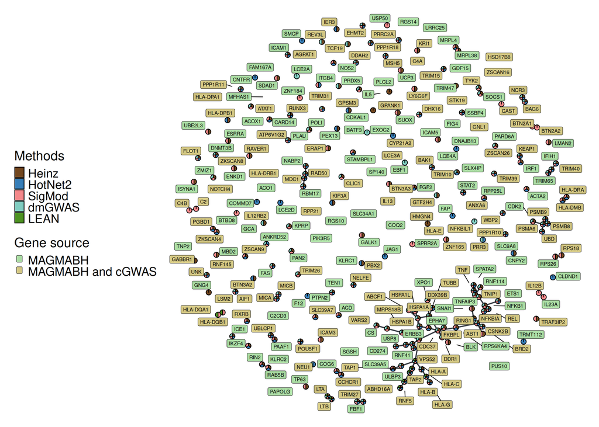

Non-network prioritisation method. We corrected for multiple tests using the Benjamini-Hochberg approach to the genes outputted by MAGMA gene-analysis step.

```r
# Heinz

g_heinz <- activate(ppi, nodes) %>%
  filter(name %in% heinz) %>%
  mutate(heinz = TRUE)
class(g_heinz) <- c('igraph','tbl_graph')

# HotNet2

g_hotnet2 <- activate(ppi, nodes) %>%
  filter(name %in% hotnet2) %>%
  mutate(hotnet2 = TRUE)
class(g_hotnet2) <- c('igraph','tbl_graph')

# SigMod

g_sigmod <- activate(ppi, nodes) %>%
  filter(name %in% sigmod) %>%
  mutate(sigmod = TRUE)
class(g_sigmod) <- c('igraph','tbl_graph')

# dmGWAS

g_dmgwas <- activate(ppi, nodes) %>%
  filter(name %in% dmgwas) %>%
  mutate(dmgwas = TRUE)
class(g_dmgwas) <- c('igraph','tbl_graph')

# LEAN

g_lean <- activate(ppi, nodes) %>%
  filter(name %in% lean) %>%
  mutate(lean = TRUE)
class(g_lean) <- c('igraph','tbl_graph')

consensus <- graph_join(g_heinz, g_hotnet2, by = c('name')) %>%
  graph_join(g_sigmod, by = c('name')) %>%
  graph_join(g_dmgwas, by = c('name')) %>%
  graph_join(g_lean, by = c('name')) %>%
  graph_join(g_magmabh_and_cgwas, by = c('name')) %>%
  graph_join(g_cgwas, by = c('name')) %>%
  graph_join(g_magmabh, by = c('name')) %>%
  to_undirected %>%
  mutate(heinz = ifelse(is.na(heinz), FALSE, heinz),
         hotnet2 = ifelse(is.na(hotnet2), FALSE, hotnet2),
         sigmod = ifelse(is.na(sigmod), FALSE, sigmod),
         dmgwas = ifelse(is.na(dmgwas), FALSE, dmgwas),
         lean = ifelse(is.na(lean), FALSE, lean),
         magmabh_and_cgwas = ifelse(is.na(magmabh_and_cgwas), FALSE, magmabh_and_cgwas),
         cgwas_genes = ifelse(is.na(cgwas_genes), FALSE, cgwas_genes),
         magmabh = ifelse(is.na(magmabh), FALSE, magmabh),
         num_methods = rowSums(cbind(heinz, hotnet2, sigmod, dmgwas, lean))) %>%
  filter(magmabh == TRUE)

set.seed(42)
consensus_gg <- consensus %>%
  ggnetwork %>%
  mutate(name = as.character(name))
nodes <- mutate(consensus_gg,
                Heinz = as.numeric(name %in% heinz_genes),
                HotNet2 = as.numeric(name %in% hotnet2_genes),
                SigMod = as.numeric(name %in% sigmod_genes),
                dmGWAS = as.numeric(name %in% dmgwas_genes),
                LEAN = as.numeric(name %in% lean_genes),
                cGWAS = as.numeric(cgwas_genes),
                MAGMABH = as.numeric(magmabh),
                MAGMABHcGWAS = as.numeric(magmabh_and_cgwas)
                ) %>%
  filter(xend == x & yend == y) %>%
  select(x, y, name, all_of(methods)) %>%
  unique

nodes <- nodes %>%
  mutate(label_group = case_when(
    MAGMABHcGWAS == 1 ~ 'MAGMABH and cGWAS',
    MAGMABH == 1 ~ 'MAGMABH',
    cGWAS == 1 ~ 'cGWAS',
    TRUE ~ 'Methods only')
  )

edges <- filter(consensus_gg, xend != x | yend != y)

# CONSENSUS PIE

consensus_pie_magmabh <- ggplot() +
  geom_edges(data = edges, aes(x = x, y = y, xend = xend, yend = yend),
             color = '#393e46', linewidth = 1) +
  geom_scatterpie(data = nodes, aes(x = x, y = y, r=0.007), cols = setdiff(methods, c('MAGMABH', 'cGWAS', 'MAGMABHcGWAS'))) +
  scale_fill_manual(name = "Methods", values = method_palette) +
  ggnewscale::new_scale_fill() +
  geom_label_repel(data = nodes,
                   aes(x = x, y = y, label = name, fill = label_group),
                   size = 3, point.padding = 1, max.time = 5, max.iter = 20000,
                   max.overlaps = 100) +
  scale_fill_manual(name = "Gene source", values = genesrc_palette) +
  coord_fixed() +
  theme_blank() +
  guides(color = "none", fill = guide_legend(
    override.aes = aes(label = "  ")
  )) +
  theme(legend.position = 'left',
        legend.text = element_text(size = 20, vjust = .2),
        legend.title = element_text(size = 22, vjust = 1)) +
  theme_transparent

consensus_pie_magmabh
```

## Consensus sensitivity — number of methods required

Consensus networks for genes selected by ≥ 1 to 5 methods, shown as panels A–E.

↑ Back to contents

```r
library(patchwork)
```

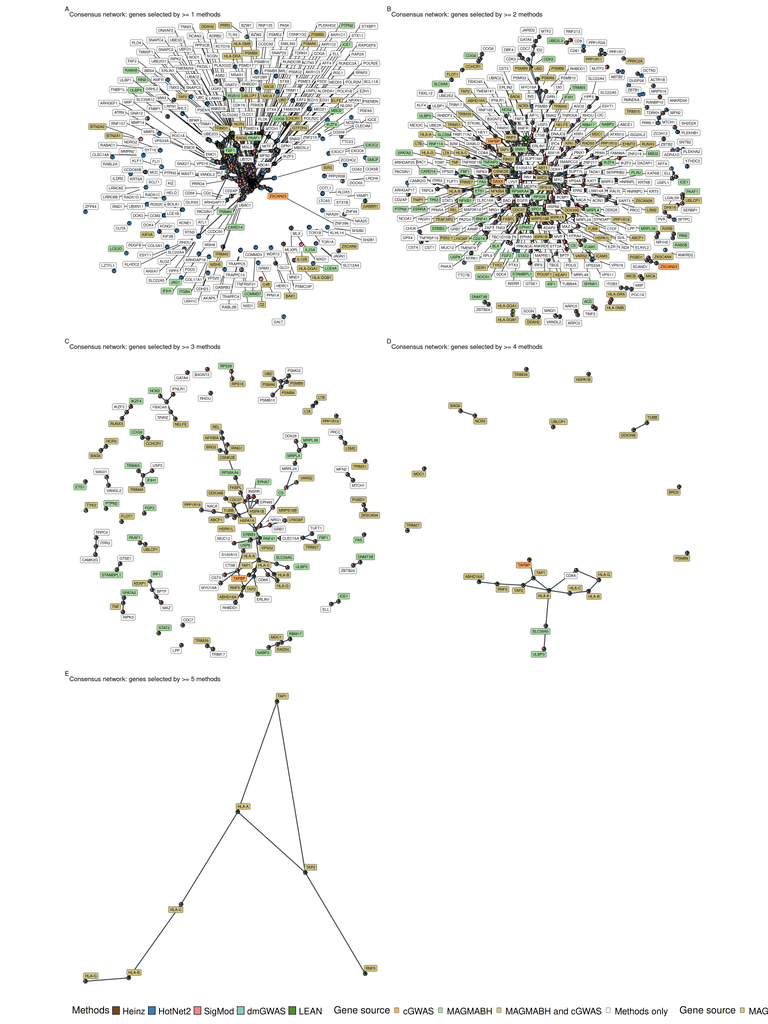

```r
# cGWAS
g_cgwas <- activate(ppi, nodes) %>%
  filter(name %in% cgwas_genes) %>%
  mutate(cgwas_genes = TRUE)
class(g_cgwas) <- c('igraph','tbl_graph')

# MAGMA_BH
g_magmabh <- activate(ppi, nodes) %>%
  filter(name %in% magmabh) %>%
  mutate(magmabh = TRUE)
class(g_magmabh) <- c('igraph','tbl_graph')

# MAGMA_BH and cGWAS
g_magmabh_and_cgwas <- activate(ppi, nodes) %>%
  filter(name %in% magmabh_and_cgwas) %>%
  mutate(magmabh_and_cgwas = TRUE)
class(g_magmabh_and_cgwas) <- c('igraph','tbl_graph')

# Heinz
g_heinz <- activate(ppi, nodes) %>%
  filter(name %in% heinz) %>%
  mutate(heinz = TRUE)
class(g_heinz) <- c('igraph','tbl_graph')

# HotNet2
g_hotnet2 <- activate(ppi, nodes) %>%
  filter(name %in% hotnet2) %>%
  mutate(hotnet2 = TRUE)
class(g_hotnet2) <- c('igraph','tbl_graph')

# SigMod
g_sigmod <- activate(ppi, nodes) %>%
  filter(name %in% sigmod) %>%
  mutate(sigmod = TRUE)
class(g_sigmod) <- c('igraph','tbl_graph')

# dmGWAS
g_dmgwas <- activate(ppi, nodes) %>%
  filter(name %in% dmgwas) %>%
  mutate(dmgwas = TRUE)
class(g_dmgwas) <- c('igraph','tbl_graph')

# LEAN
g_lean <- activate(ppi, nodes) %>%
  filter(name %in% lean) %>%
  mutate(lean = TRUE)
class(g_lean) <- c('igraph','tbl_graph')

make_consensus_plot <- function(n) {

  consensus <- graph_join(g_heinz, g_hotnet2, by = 'name') %>%
    graph_join(g_sigmod, by = 'name') %>%
    graph_join(g_dmgwas, by = 'name') %>%
    graph_join(g_lean, by = 'name') %>%
    graph_join(g_magmabh_and_cgwas, by = 'name') %>%
    graph_join(g_cgwas, by = 'name') %>%
    graph_join(g_magmabh, by = 'name') %>%
    to_undirected %>%
    mutate(heinz = ifelse(is.na(heinz), FALSE, heinz),
           hotnet2 = ifelse(is.na(hotnet2), FALSE, hotnet2),
           sigmod = ifelse(is.na(sigmod), FALSE, sigmod),
           dmgwas = ifelse(is.na(dmgwas), FALSE, dmgwas),
           lean = ifelse(is.na(lean), FALSE, lean),
           magmabh_and_cgwas = ifelse(is.na(magmabh_and_cgwas), FALSE, magmabh_and_cgwas),
           cgwas_genes = ifelse(is.na(cgwas_genes), FALSE, cgwas_genes),
           magmabh = ifelse(is.na(magmabh), FALSE, magmabh),
           num_methods = rowSums(cbind(heinz, hotnet2, sigmod, dmgwas, lean))) %>%
    filter(num_methods >= n)

  set.seed(42)
  consensus_gg <- consensus %>%
    ggnetwork %>%
    mutate(name = as.character(name))

  nodes <- mutate(consensus_gg,
                  Heinz = as.numeric(name %in% heinz_genes),
                  HotNet2 = as.numeric(name %in% hotnet2_genes),
                  SigMod = as.numeric(name %in% sigmod_genes),
                  dmGWAS = as.numeric(name %in% dmgwas_genes),
                  LEAN = as.numeric(name %in% lean_genes),
                  cGWAS = as.numeric(cgwas_genes),
                  MAGMABH = as.numeric(magmabh),
                  MAGMABHcGWAS = as.numeric(magmabh_and_cgwas)) %>%
    filter(xend == x & yend == y) %>%
    select(x, y, name, all_of(methods)) %>%
    unique

  nodes <- nodes %>%
    mutate(label_group = case_when(
      MAGMABHcGWAS == 1 ~ 'MAGMABH and cGWAS',
      MAGMABH == 1 ~ 'MAGMABH',
      cGWAS == 1 ~ 'cGWAS',
      TRUE ~ 'Methods only'))

  edges <- filter(consensus_gg, xend != x | yend != y)

  ggplot() +
    geom_edges(data = edges, aes(x = x, y = y, xend = xend, yend = yend),
               color = '#393e46', linewidth = 1) +
    geom_scatterpie(data = nodes, aes(x = x, y = y, r = 0.007),
                    cols = setdiff(methods, c('MAGMABH', 'cGWAS', 'MAGMABHcGWAS'))) +
    scale_fill_manual(name = "Methods", values = method_palette, drop = FALSE) +
    ggnewscale::new_scale_fill() +
    geom_label_repel(data = nodes,
                     aes(x = x, y = y, label = name, fill = label_group),
                     size = 3, point.padding = 1, max.time = 5, max.iter = 20000,
                     max.overlaps = 100) +
    scale_fill_manual(name = "Gene source", values = genesrc_palette, drop = FALSE) +
    coord_fixed() +
    theme_blank() +
    guides(color = "none", fill = guide_legend(override.aes = aes(label = "  "))) +
    theme(legend.position = 'left',
          legend.text = element_text(size = 20, vjust = .2),
          legend.title = element_text(size = 22, vjust = 1)) +
    theme_transparent +
    ggtitle(paste0("Consensus network: genes selected by >= ", n, " methods"))
}

# Build one plot per threshold
consensus_plots <- lapply(1:5, make_consensus_plot)
# Combine into one figure (2 columns x 3 rows)
wrap_plots(consensus_plots, ncol = 2) +
  plot_layout(guides = "collect") +
  plot_annotation(tag_levels = 'A') &
  theme(legend.position = "bottom")
```

## Robustness to the prior-knowledge network

Consensus networks rebuilt with HINT (a), IID (b), IntAct (c) and STRING (d) instead of BioGRID.

↑ Back to contents

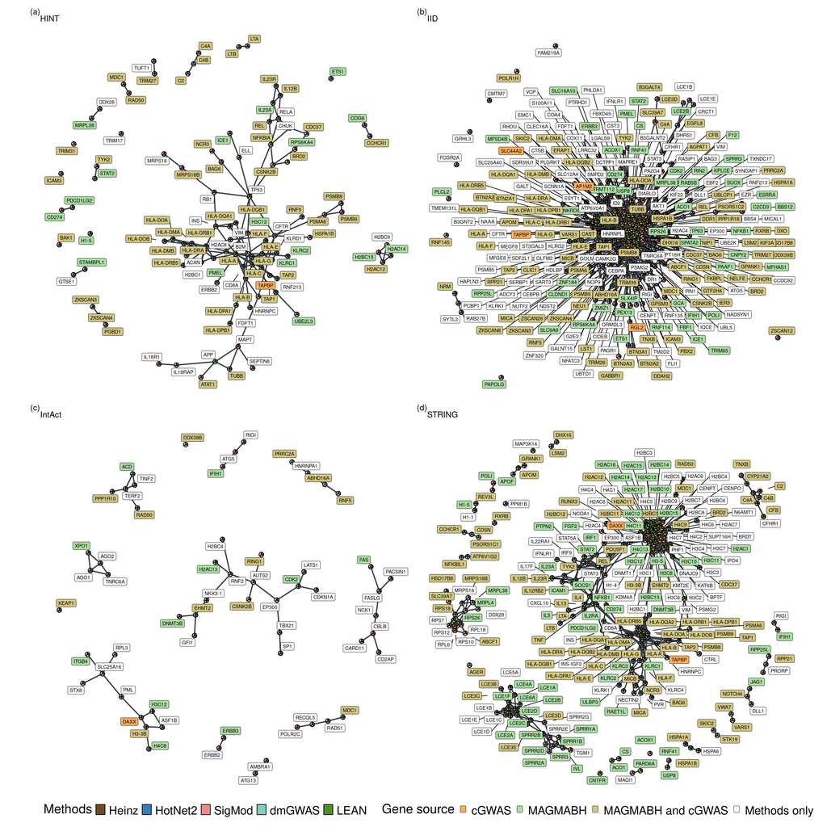

Robustness of the consensus network built by changing the biological prior knowledge network: High-quality INTeractomes (HINT) (a), Integrated Interactions Database (IID) (b), IntAct Molecular Interaction Database (c), and Search Tool for Recurring Instances of Neighbouring Genes (STRING) (d).

```r
library(patchwork)

# Folder of each network and the path to its PPI file
networks <- list(
  HINT   = list(dir = 'data/other_networks/hint/',
                ppi_file = 'data/other_networks/hint/hint_homo_sapiens_lcb_hq_hgnc.tsv'),
  IID    = list(dir = 'data/other_networks/iid/',
                ppi_file = 'data/other_networks/iid/human_annotated_integrated_interactions_database_skin_not_sun_exposed_exp.tsv'),
  IntAct = list(dir = 'data/other_networks/intact/',
                ppi_file = 'data/other_networks/intact/intact_human_association_physical_direct_interaction_types_2026-04-14-10-00_hgnc.tsv'),
  STRING = list(dir = 'data/other_networks/string/',
                ppi_file = 'data/other_networks/string/9606.protein.links.v12.0.min900.onlyAB_hgnc.tsv')
)

# Read a PPI file with two gene columns and return a tbl_graph
read_ppi <- function(path) {
  read_tsv(path, col_types = cols(.default = 'c')) %>%
    select(`Official Symbol Interactor A`, `Official Symbol Interactor B`) %>%
    graph_from_data_frame(directed = FALSE) %>%
    as_tbl_graph
}

build_consensus_plot <- function(net_name, net, n = 3) {

  ppi <- read_ppi(net$ppi_file)
  d <- net$dir

  # Method outputs for this network
  heinz   <- read_tsv(file.path(d, 'heinz/selected_genes_split_1.heinz.txt'), col_types = 'c')$gene
  hotnet2 <- read_tsv(file.path(d, 'hotnet2/selected_genes_split_1.hotnet2.tsv'), col_types = 'cc')$gene
  sigmod  <- read_tsv(file.path(d, 'sigmod/selected_genes_split_1.sigmod.txt'), col_types = 'c')$gene
  dmgwas  <- read_tsv(file.path(d, 'dmgwas/selected_genes_split_1.dmgwas.txt'), col_types = 'c')$gene
  lean    <- read_tsv(file.path(d, 'lean/selected_genes_split_1.lean.txt'), col_types = 'c')$gene

  # Helper to create one subgraph per gene set
  make_sub <- function(genes, label) {
    g <- activate(ppi, nodes) %>%
      filter(name %in% genes) %>%
      mutate(!!label := TRUE)
    class(g) <- c('igraph', 'tbl_graph')
    g
  }

  g_cgwas             <- make_sub(cgwas_genes, 'cgwas_genes')
  g_magmabh           <- make_sub(magmabh, 'magmabh')
  g_magmabh_and_cgwas <- make_sub(magmabh_and_cgwas, 'magmabh_and_cgwas')
  g_heinz             <- make_sub(heinz, 'heinz')
  g_hotnet2           <- make_sub(hotnet2, 'hotnet2')
  g_sigmod            <- make_sub(sigmod, 'sigmod')
  g_dmgwas            <- make_sub(dmgwas, 'dmgwas')
  g_lean              <- make_sub(lean, 'lean')

  consensus <- graph_join(g_heinz, g_hotnet2, by = 'name') %>%
    graph_join(g_sigmod, by = 'name') %>%
    graph_join(g_dmgwas, by = 'name') %>%
    graph_join(g_lean, by = 'name') %>%
    graph_join(g_magmabh_and_cgwas, by = 'name') %>%
    graph_join(g_cgwas, by = 'name') %>%
    graph_join(g_magmabh, by = 'name') %>%
    to_undirected %>%
    mutate(heinz = ifelse(is.na(heinz), FALSE, heinz),
           hotnet2 = ifelse(is.na(hotnet2), FALSE, hotnet2),
           sigmod = ifelse(is.na(sigmod), FALSE, sigmod),
           dmgwas = ifelse(is.na(dmgwas), FALSE, dmgwas),
           lean = ifelse(is.na(lean), FALSE, lean),
           magmabh_and_cgwas = ifelse(is.na(magmabh_and_cgwas), FALSE, magmabh_and_cgwas),
           cgwas_genes = ifelse(is.na(cgwas_genes), FALSE, cgwas_genes),
           magmabh = ifelse(is.na(magmabh), FALSE, magmabh),
           num_methods = rowSums(cbind(heinz, hotnet2, sigmod, dmgwas, lean))) %>%
    filter(num_methods >= n)

  set.seed(42)
  consensus_gg <- consensus %>%
    ggnetwork %>%
    mutate(name = as.character(name))

  nodes <- mutate(consensus_gg,
                  Heinz = as.numeric(heinz),
                  HotNet2 = as.numeric(hotnet2),
                  SigMod = as.numeric(sigmod),
                  dmGWAS = as.numeric(dmgwas),
                  LEAN = as.numeric(lean),
                  cGWAS = as.numeric(cgwas_genes),
                  MAGMABH = as.numeric(magmabh),
                  MAGMABHcGWAS = as.numeric(magmabh_and_cgwas)) %>%
    filter(xend == x & yend == y) %>%
    select(x, y, name, all_of(methods)) %>%
    unique

  nodes <- nodes %>%
    mutate(label_group = case_when(
      MAGMABHcGWAS == 1 ~ 'MAGMABH and cGWAS',
      MAGMABH == 1 ~ 'MAGMABH',
      cGWAS == 1 ~ 'cGWAS',
      TRUE ~ 'Methods only'))

  edges <- filter(consensus_gg, xend != x | yend != y)


  # stop("DEBUG: nodes columns are: ", paste(names(nodes), collapse = ", "))

  ggplot() +
    geom_edges(data = edges, aes(x = x, y = y, xend = xend, yend = yend),
               color = '#393e46', linewidth = 1) +
    geom_scatterpie(data = nodes, aes(x = x, y = y, r = 0.007),
                    cols = setdiff(methods, c('MAGMABH', 'cGWAS', 'MAGMABHcGWAS'))) +
    scale_fill_manual(name = "Methods", values = method_palette, drop = FALSE) +
    ggnewscale::new_scale_fill() +
    geom_label_repel(data = nodes,
                     aes(x = x, y = y, label = name, fill = label_group),
                     size = 3, point.padding = 1, max.time = 5, max.iter = 20000,
                     max.overlaps = 100) +
    scale_fill_manual(name = "Gene source", values = genesrc_palette, drop = FALSE) +
    coord_fixed() +
    theme_blank() +
    guides(color = "none", fill = guide_legend(override.aes = aes(label = "  "))) +
    theme(legend.position = 'left',
          legend.text = element_text(size = 20, vjust = .2),
          legend.title = element_text(size = 22, vjust = 1)) +
    theme_transparent +
    ggtitle(net_name)
}

# One plot per network
consensus_plots <- map2(names(networks), networks, build_consensus_plot)
# Combine into a 2 x 2 figure labelled (a) to (d)
wrap_plots(consensus_plots, ncol = 2) +
  plot_layout(guides = 'collect') +
  plot_annotation(tag_levels = 'a', tag_prefix = '(', tag_suffix = ')') &
  theme(legend.position = 'bottom')
```

## Comparison between datasets

↑ Back to contents

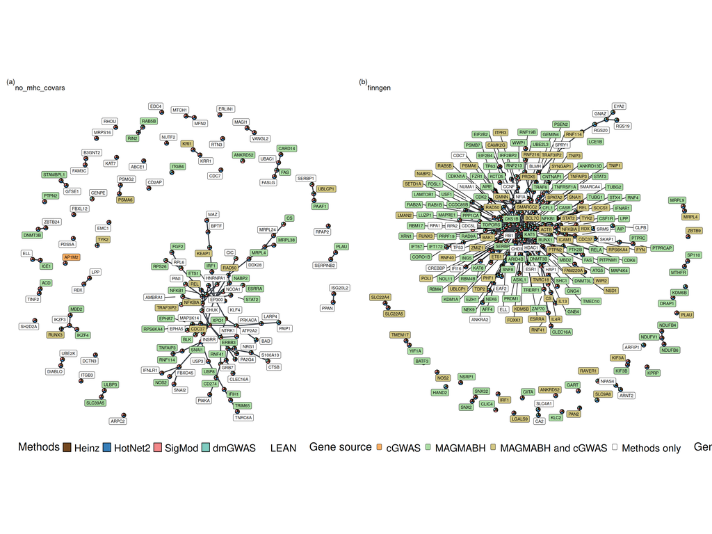

Comparison between two different datasets. Subfigure (a) illustrates the dataset used in this study, but excluding the MHC region, and integrating covariates, subfigure (b) shows the consensus network obtained by applying the pipeline to the psoriasis summary statistics from Finngen.

```r
library(patchwork)

# Folder of each network and the path to its PPI file
datasets <- list(
  no_mhc_covars = list(
    dir        = 'data/no_mhc_covars/',
    ppi_file   = 'data/biogrid_mv_physical_4.4.249_tab2_onlyhuman_9606_interactorsAB.tsv',
    cgwas_file = 'data/pso.genes.annot_gene_ids_names.tsv',
    magma_file = 'data/no_mhc_covars/pso.scores.genes.out_converted_pruned_bhcorrection.tsv'
  ),
  finngen = list(
    dir        = 'data/finngen/',
    ppi_file   = 'data/biogrid_mv_physical_4.4.249_tab2_onlyhuman_9606_interactorsAB.tsv',
    cgwas_file = 'data/finngen/finngen_R12_L12_PSORIASIS_autosomes_only_snps_no_mhc.genes.annot_gene_ids_names.tsv',
    magma_file = 'data/finngen/finngen_R12_L12_PSORIASIS_autosomes_only_snps_no_mhc.scores.genes.out_converted_bhcorrection.tsv'
  )
)

# Read a PPI file with two gene columns and return a tbl_graph
read_ppi <- function(path) {
  read_tsv(path, col_types = cols(.default = 'c')) %>%
    select(`Official Symbol Interactor A`, `Official Symbol Interactor B`) %>%
    graph_from_data_frame(directed = FALSE) %>%
    as_tbl_graph
}

build_consensus_plot <- function(data_name, dataset, n = 3) {

  ppi <- read_ppi(dataset$ppi_file)
  d <- dataset$dir

  # Method outputs for this network
  cgwas_genes <- read_tsv(dataset$cgwas_file, col_types = 'c')$Gene %>% unique()
  magmabh     <- read_tsv(dataset$magma_file, col_types = 'iiciiiiiidnn')$Gene %>% unique()
  magmabh_and_cgwas <- intersect(magmabh, cgwas_genes)

  heinz   <- read_tsv(file.path(d, 'heinz/selected_genes_split_1.heinz.txt'), col_types = 'c')$gene
  hotnet2 <- read_tsv(file.path(d, 'hotnet2/selected_genes_split_1.hotnet2.tsv'), col_types = 'cc')$gene
  sigmod  <- read_tsv(file.path(d, 'sigmod/selected_genes_split_1.sigmod.txt'), col_types = 'c')$gene
  dmgwas  <- read_tsv(file.path(d, 'dmgwas/selected_genes_split_1.dmgwas.txt'), col_types = 'c')$gene
  lean    <- read_tsv(file.path(d, 'lean/selected_genes_split_1.lean.txt'), col_types = 'c')$gene

  # Helper to create one subgraph per gene set
  make_sub <- function(genes, label) {
    g <- activate(ppi, nodes) %>%
      filter(name %in% genes) %>%
      mutate(!!label := TRUE)
    class(g) <- c('igraph', 'tbl_graph')
    g
  }

  g_cgwas             <- make_sub(cgwas_genes, 'cgwas_genes')
  g_magmabh           <- make_sub(magmabh, 'magmabh')
  g_magmabh_and_cgwas <- make_sub(magmabh_and_cgwas, 'magmabh_and_cgwas')
  g_heinz             <- make_sub(heinz, 'heinz')
  g_hotnet2           <- make_sub(hotnet2, 'hotnet2')
  g_sigmod            <- make_sub(sigmod, 'sigmod')
  g_dmgwas            <- make_sub(dmgwas, 'dmgwas')
  g_lean              <- make_sub(lean, 'lean')

  consensus <- graph_join(g_heinz, g_hotnet2, by = 'name') %>%
    graph_join(g_sigmod, by = 'name') %>%
    graph_join(g_dmgwas, by = 'name') %>%
    graph_join(g_lean, by = 'name') %>%
    graph_join(g_magmabh_and_cgwas, by = 'name') %>%
    graph_join(g_cgwas, by = 'name') %>%
    graph_join(g_magmabh, by = 'name') %>%
    to_undirected %>%
    mutate(heinz = ifelse(is.na(heinz), FALSE, heinz),
           hotnet2 = ifelse(is.na(hotnet2), FALSE, hotnet2),
           sigmod = ifelse(is.na(sigmod), FALSE, sigmod),
           dmgwas = ifelse(is.na(dmgwas), FALSE, dmgwas),
           lean = ifelse(is.na(lean), FALSE, lean),
           magmabh_and_cgwas = ifelse(is.na(magmabh_and_cgwas), FALSE, magmabh_and_cgwas),
           cgwas_genes = ifelse(is.na(cgwas_genes), FALSE, cgwas_genes),
           magmabh = ifelse(is.na(magmabh), FALSE, magmabh),
           num_methods = rowSums(cbind(heinz, hotnet2, sigmod, dmgwas, lean))) %>%
    filter(num_methods >= n)

  set.seed(42)
  consensus_gg <- consensus %>%
    ggnetwork %>%
    mutate(name = as.character(name))

  nodes <- mutate(consensus_gg,
                  Heinz = as.numeric(heinz),
                  HotNet2 = as.numeric(hotnet2),
                  SigMod = as.numeric(sigmod),
                  dmGWAS = as.numeric(dmgwas),
                  LEAN = as.numeric(lean),
                  cGWAS = as.numeric(cgwas_genes),
                  MAGMABH = as.numeric(magmabh),
                  MAGMABHcGWAS = as.numeric(magmabh_and_cgwas)) %>%
    filter(xend == x & yend == y) %>%
    select(x, y, name, all_of(methods)) %>%
    unique

  nodes <- nodes %>%
    mutate(label_group = case_when(
      MAGMABHcGWAS == 1 ~ 'MAGMABH and cGWAS',
      MAGMABH == 1 ~ 'MAGMABH',
      cGWAS == 1 ~ 'cGWAS',
      TRUE ~ 'Methods only'))

  edges <- filter(consensus_gg, xend != x | yend != y)


  # stop("DEBUG: nodes columns are: ", paste(names(nodes), collapse = ", "))

  ggplot() +
    geom_edges(data = edges, aes(x = x, y = y, xend = xend, yend = yend),
               color = '#393e46', linewidth = 1) +
    geom_scatterpie(data = nodes, aes(x = x, y = y, r = 0.007),
                    cols = setdiff(methods, c('MAGMABH', 'cGWAS', 'MAGMABHcGWAS'))) +
    scale_fill_manual(name = "Methods", values = method_palette, drop = FALSE) +
    ggnewscale::new_scale_fill() +
    geom_label_repel(data = nodes,
                     aes(x = x, y = y, label = name, fill = label_group),
                     size = 3, point.padding = 1, max.time = 5, max.iter = 20000,
                     max.overlaps = 100) +
    scale_fill_manual(name = "Gene source", values = genesrc_palette, drop = FALSE) +
    coord_fixed() +
    theme_blank() +
    guides(color = "none", fill = guide_legend(override.aes = aes(label = "  "))) +
    theme(legend.position = 'left',
          legend.text = element_text(size = 20, vjust = .2),
          legend.title = element_text(size = 22, vjust = 1)) +
    theme_transparent +
    ggtitle(data_name)
}

# One plot per network
consensus_plots <- map2(names(datasets), datasets, build_consensus_plot)
# Combine into a figure labelled (a) to (b)
wrap_plots(consensus_plots, ncol = 2) +
  plot_layout(guides = 'collect') +
  plot_annotation(tag_levels = 'a', tag_prefix = '(', tag_suffix = ')') &
  theme(legend.position = 'bottom')
```